# Coursera project

# Loading and preprocessing the data

1. Load the data (i.e. read.csv())
2. Process/transform the data (if necessary) into a format suitable for your analysis

```r
library(plyr)
library(dplyr)
dat <- read.csv('activity.csv')
```

# What is mean total number of steps taken per day?

1. Calculate the total number of steps taken per day

```r
cdata <- ddply(dat, "date", summarise,
               steps_per_day = sum(steps)
)
cdata
```

```
##          date steps_per_day
## 1  2012-10-01            NA
## 2  2012-10-02           126
## 3  2012-10-03         11352
## 4  2012-10-04         12116
## 5  2012-10-05         13294
## 6  2012-10-06         15420
## 7  2012-10-07         11015
## 8  2012-10-08            NA
## 9  2012-10-09         12811
## 10 2012-10-10          9900
## 11 2012-10-11         10304
## 12 2012-10-12         17382
## 13 2012-10-13         12426
## 14 2012-10-14         15098
```

[output cut: 47 more lines]

2. Make a histogram of the total number of steps taken each day

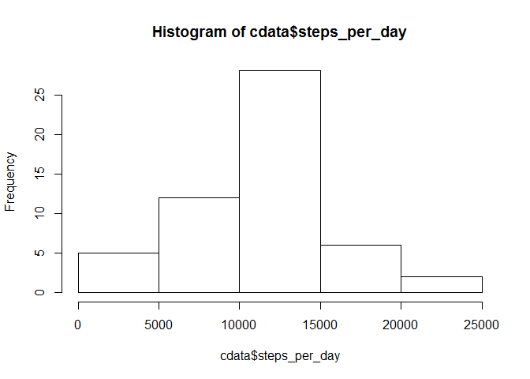

```r
hist(cdata$steps_per_day)
```

3. Calculate and report the mean and median of the total number of steps taken per day

```r
mean(cdata$steps_per_day, na.rm=TRUE)
```

```
## [1] 10766.19
```

```r
median(cdata$steps_per_day, na.rm=TRUE)
```

```
## [1] 10765
```

# What is the average daily activity pattern?

1. Make a time series plot (i.e. type = “l”) of the 5-minute interval (x-axis) and the average number of steps taken, averaged across all days (y-axis)

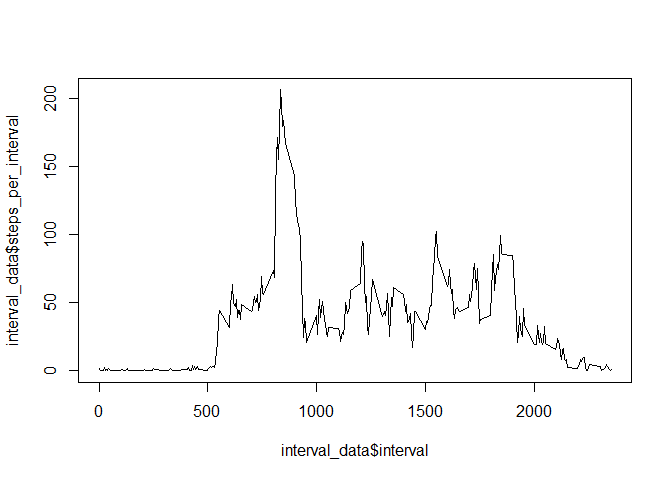

```r
interval_data <- ddply(dat, "interval", summarise,
               steps_per_interval = mean(steps, na.rm=TRUE)
)

 plot(interval_data$interval, interval_data$steps_per_interval, type = "l")
```

2. Which 5-minute interval, on average across all the days in the dataset, contains the maximum number of steps?

```r
index <- which(interval_data$steps_per_interval==max(interval_data$steps_per_interval))
interval_data[index,"interval"]
```

```
## [1] 835
```